# iMKT using PopFly or PopHuman data

The improvement of NGS technologies that lead to the sequencing of hundreds or even thousands of individuals from the same species provides us with the necessary data on which to empirically test evolutionary theoretical hypotheses. The availability of such datasets increases the request of developing high performance specific tools able to deal and analyze this information.

The PopFly (Hervas et al. 2017) and PopHuman (Casillas et al. 2018) genome browsers are the two central repositories of population genomics estimates for *Drosophila melanogaster* and *Homo sapiens* model species, respectively. Thus, we decided to provide functionalities to directly link the iMKT software to both databases, which allows retrieving and analyzing population genomics information in a single step.

Therefore, iMKT package includes some functions which allow an easy retrieval and analysis of population genetics information stored in these genome browsers. Specifically, the functions permit the download of population genetics parameters computed for every gene annotation in several populations for both model species.

This vignette is divided in two main sections:

- Loading the raw data
- Performing iMKT analyses

Although the examples presented here focus only on PopFly data and analyses, the same process could be performed using human data and functions (**PopHumanData**, **loadPopHuman()**, **PopHumanAnalysis()**), following the same steps described in this document. Recombination rate values included in human data were retrieved from Bhérer et al. (2017) and correspond to the sex average estimates, while for *D. melanogaster* comes from Comeron et al. (2012).

## Loading the raw data

The first step is to load the information into your working environment. This would allow a manual examination of the data before starting any analysis. However, to speed analyses, this step can be skipped and the main data object is loaded into the workspace the first time that the corresponding analysis function is called. To download PopFly data use the **loadPopFly()** function, without any argument.

Keep in mind that you are downloading full-genome information of several populations (13,753 gene annotations for 16 populations in *D.melanogaster* and 20,643 gene annotations for 26 populations in *H. sapiens*), and this process could take a while.

Once the function finishes,the **PopFlyData** object is loaded into the workspace. This object can be manually examined or used when performing iMKT analyses.

```r
## Load the iMKT library
library(iMKT)

## Load PopFlyData
loadPopFly()
```

```
#> Loading PopFly data into your workspace.
#> This process may take several seconds to complete, please be patient.
```

```r
## Check data object
ls()
```

```
#> [1] "PopFlyData"
```

```r
names(PopFlyData)
```

```
#>  [1] "Name"  "Pop"   "DAF0f" "DAF4f" "p0"    "pi"    "di"    "d0"    "Chr"
#> [10] "mi"    "m0"    "cM_Mb"
```

Once the data is loaded into the workspace, diverse iMKT analyses can be performed using the function **PopFlyAnalysis()**.

## Performing iMKT Analyses

The **PopFlyAnalysis()** function allows performing any MK test using a subset of PopFly data defined by custom genes and populations lists. It uses the previously loaded dataframe (PopFlyData). In addition to the **genes** and **populations** lists, the function also has the following parameters:

- **recomb**: group genes according to recombination values (TRUE/FALSE)
- **bins**: number of recombination bins to compute (mandatory if `recomb=TRUE`)
- **test**: which test to perform. Options include: `standardMKT` (default), `imputedMKT`, `eMKT`, `FWW`, `aMKT`
- **xlow**: lower limit for asymptotic alpha fit (default=0)
- **xhigh**: higher limit for asymptotic alpha fit (default=1)
- **plot**: report plot (optional, default=FALSE)

Custom genes must be listed using FlyBase IDs (FBgn…), and the available populations from PopFly are: AM, AUS, CHB, EA, EF, EG, ENA, EQA, FR, RAL, SA, SD, SP, USI, USW, ZI.

Hence, using the parameters `recomb` and `bins`, the function allows deciding whether to analyze genes grouped by recombination bins or not.

### Example 1. imputedMKT analysis without recombination

In this first example, the analysis is focused in two genes and two populations, without considering gene’s recombination context, and using the `imputedMKT` methodology.

The function groups polymorphism and divergence values of the custom genes, creating a new “concatenated gene” for each population of interest and performs the test defined. Then, it returns a list of lists with the default test output (`imputedMKT` in this case) for each population (RAL and ZI).

```
#> [1] "Population = RAL"
#> `geom_line()`: Each group consists of only one observation.
#> ℹ Do you need to adjust the group aesthetic?
#> [1] "Population = ZI"
#> `geom_line()`: Each group consists of only one observation.
#> ℹ Do you need to adjust the group aesthetic?
#> $`Population =  RAL`
#> $`Population =  RAL`$mktTable
#>                Polymorphism Divergence
#> Neutral class            60         45
#> Selected class           36         13
#>
#> $`Population =  RAL`$alphaCorrected
#>             cutoff alphaCorrected    pvalue
#> cutoff=0.05   0.05       0.291958 0.5031151
#>
#> $`Population =  RAL`$divMetrics
#> $`Population =  RAL`$divMetrics$metricsByCutoff
#>             cutoff          Ka         Ks     omegaA     omegaD
#> cutoff=0.05   0.05 0.003747478 0.05208333 0.02100684 0.05094473
#>
#>
#> $`Population =  RAL`$fractions
#>             cutoff         d          f          b
#> cutoff=0.05   0.05 0.8505621 0.05094473 0.09849315
#>
#> $`Population =  RAL`$graph
```

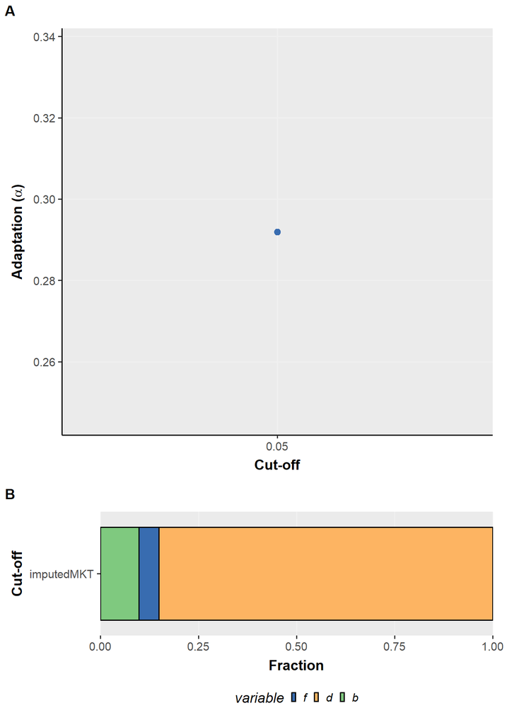

```
#>
#>
#> $`Population =  ZI`
#> $`Population =  ZI`$mktTable
#>                Polymorphism Divergence
#> Neutral class           144         40
#> Selected class           81         14
#>
#> $`Population =  ZI`$alphaCorrected
#>             cutoff alphaCorrected     pvalue
#> cutoff=0.05   0.05      0.5573441 0.03518024
#>
#> $`Population =  ZI`$divMetrics
#> $`Population =  ZI`$divMetrics$metricsByCutoff
#>             cutoff          Ka        Ks     omegaA     omegaD
#> cutoff=0.05   0.05 0.004035745 0.0462963 0.04858485 0.03858725
#>
#>
#> $`Population =  ZI`$fractions
#>             cutoff        d          f         b
#> cutoff=0.05   0.05 0.859902 0.03858725 0.1015108
#>
#> $`Population =  ZI`$graph
```

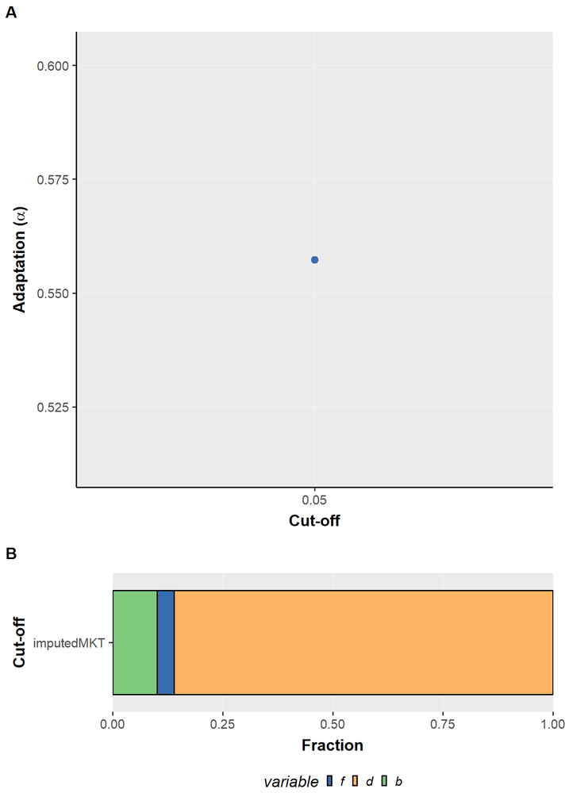

```r
PopFlyAnalysis(genes=c("FBgn0000055","FBgn0003016"), pops=c("RAL","ZI"), recomb=F, test="imputedMKT", plot=TRUE)
```

### Example 2. aMKT analysis using recombination bins

In this second example, genes from RAL population are grouped in three recombination bins, using recombination values from Comeron et al. (2012). The test used is `aMKT`, with `xlow` and `xhigh` values set to 0 and 0.9, respectively. We are analyzing the complete set of genes located in the chromosome 2R ($n=2,822$)

In this case, the function creates three different “concatenated” genes (941, 940 and 941 genes, respectively), grouping again polymorphism and divergence values. These aggrupations are made according to the gene associated recombination rate estimates. The function returns a list of lists with the default test output (`aMKT` in this case) for each population (RAL) and recombination bin (1, 2 and 3).

The output of the function is a list that contains:

- **Asymptotic MK table**: table including information about the model type (exponential) along with the fitted function values ($a$, $b$, $c$), the $\alpha$ asymptotic estimate with its corresponding lower and higher confidence interval values, and the $\alpha$ original estimate (using the standard MKT methodology and the polymorphic sites within the `xlow` and `xhigh` cutoffs)
- **Fractions of sites**: negative selection fractions ($d$: strongly deleterious, $f$: neutral and $b$: weakly deleterious)
- **Graphs**: 3 plots showing **(A)** the distribution of allele frequencies (DAF) for neutral and selected sites, **(B)** the adaptation values ($\alpha$) for each DAF category along with the function fit, the $\alpha$ asymptotic and $\alpha$ original estimates and the limits used for function fitting and adaptation values calculation, and **(C)** the negative selection fractions

```
#> [1] "Population = RAL"
#> [1] "Recombination bin = 1"
#> [1] "Recombination bin = 2"
#> [1] "Recombination bin = 3"
#> $`Population =  RAL`
#> $`Population =  RAL`$`Recombination bin =  1`
#> $`Population =  RAL`$`Recombination bin =  1`$alphaCorrected
#>         model      a       b       c alphaAsymptotic  ciLow ciHigh
#> 1 exponential 0.5364 -1.9461 12.7705          0.5364 0.4857 0.5865
#>   alphaOriginal
#> 1        -0.095
#>
#> $`Population =  RAL`$`Recombination bin =  1`$fractions
#>           d          f         b
#> 1 0.7810309 0.09572821 0.1232409
#>
#> $`Population =  RAL`$`Recombination bin =  1`$graphs
```

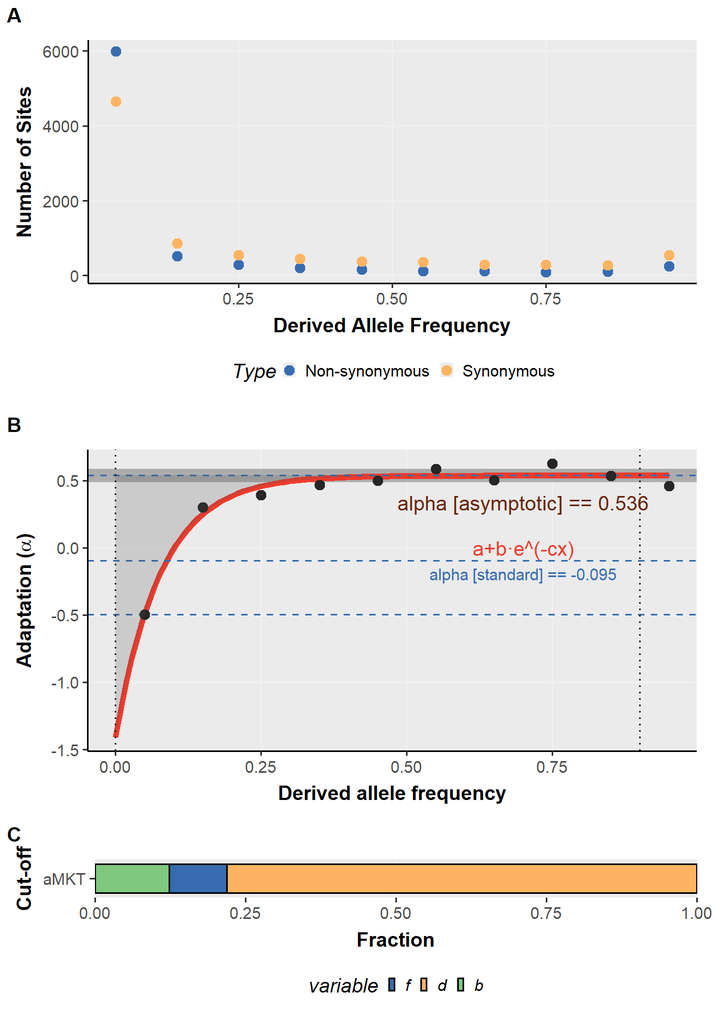

```
#>
#> $`Population =  RAL`$`Recombination bin =  1`$`Recombination bin Summary`
#>   numGenes minRecomb medianRecomb meanRecomb maxRecomb
#> 1      941         0    0.9761777  0.9078256  1.735427
#>
#>
#> $`Population =  RAL`$`Recombination bin =  2`
#> $`Population =  RAL`$`Recombination bin =  2`$alphaCorrected
#>         model      a      b       c alphaAsymptotic  ciLow ciHigh alphaOriginal
#> 1 exponential 0.6625 -1.561 15.6528          0.6625 0.6354 0.6896        0.2692
#>
#> $`Population =  RAL`$`Recombination bin =  2`$fractions
#>           d          f          b
#> 1 0.8185603 0.08582883 0.09561088
#>
#> $`Population =  RAL`$`Recombination bin =  2`$graphs
```

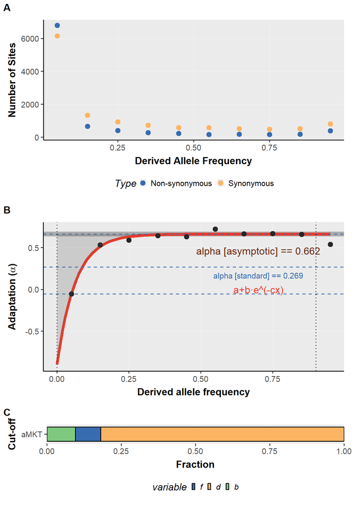

```
#>
#> $`Population =  RAL`$`Recombination bin =  2`$`Recombination bin Summary`
#>   numGenes minRecomb medianRecomb meanRecomb maxRecomb
#> 1      940  1.735427     2.386212   2.470906  3.253926
#>
#>
#> $`Population =  RAL`$`Recombination bin =  3`
#> $`Population =  RAL`$`Recombination bin =  3`$alphaCorrected
#>         model      a       b      c alphaAsymptotic  ciLow ciHigh alphaOriginal
#> 1 exponential 0.6525 -1.7825 17.172          0.6525 0.6049 0.6983        0.2526
#>
#> $`Population =  RAL`$`Recombination bin =  3`$fractions
#>           d          f        b
#> 1 0.8322388 0.08033417 0.087427
#>
#> $`Population =  RAL`$`Recombination bin =  3`$graphs
```

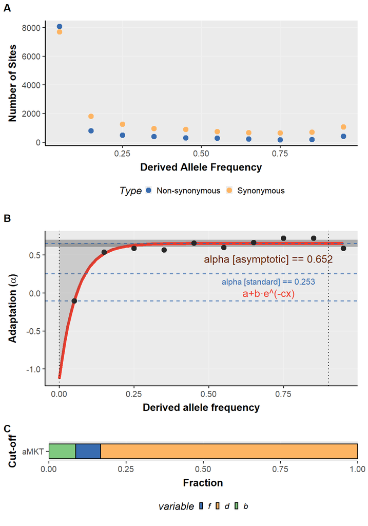

```
#>
#> $`Population =  RAL`$`Recombination bin =  3`$`Recombination bin Summary`
#>   numGenes minRecomb medianRecomb meanRecomb maxRecomb
#> 1      941  3.253926     4.555496   5.241239  8.894063
```

```r
geneList <- as.vector(unique(PopFlyData[PopFlyData$Chr=="2R",]$Name))
PopFlyAnalysis(genes=geneList , pops="RAL", recomb=T, bins=3, test="aMKT", xlow=0, xhigh=0.9, plot=TRUE)
```

## References

Bhérer, Claude, Christopher L. Campbell, and Adam Auton. 2017. “Refined Genetic Maps Reveal Sexual Dimorphism in Human Meiotic Recombination at Multiple Scales.” *Nature Communications* 8 (1): 14994. https://doi.org/10.1038/ncomms14994.

Casillas, Sònia, Roger Mulet, Pablo Villegas-Mirón, et al. 2018. “PopHuman: The Human Population Genomics Browser.” *Nucleic Acids Research* 46 (D1): D1003–10. https://doi.org/10.1093/nar/gkx943.

Comeron, Josep M., Ramesh Ratnappan, and Samuel Bailin. 2012. “The Many Landscapes of Recombination in Drosophila Melanogaster.” *PLoS Genetics* 8 (10): e1002905. https://doi.org/10.1371/journal.pgen.1002905.

Hervas, Sergi, Esteve Sanz, Sònia Casillas, John E. Pool, and Antonio Barbadilla. 2017. “PopFly: The Drosophila Population Genomics Browser.” *Bioinformatics* (Oxford, England) 33 (17): 2779–80. https://doi.org/10.1093/bioinformatics/btx301.